# Kucma_Goreczny_projekt

Źródło danych: https://archive.ics.uci.edu/ml/datasets/polish+companies+bankruptcy+data (a właściwie ich część) Wykorzystane dane, to dane dotyczące kilku tysięcy polskich firm na przestrzeni lat 2000-2013. Analizie poddano przedsiębiorstwa upadłe w latach 2000-2012, natomiast przedsiębiorstwa nadal działające w latach 2007-2013. Zbiór danych zawiera wartości kilkudziesięciu zmiennych opisujących sytuację finansową każdej z niemal siedmiu tysięcy analizowanych firm oraz informację o tym, czy dana firma zbankurtowała w badanym okresie czy też nie(0 w ostatniej kolumnie to brak bankurctwa - 1 to bankructwo).

((Są to te same dane co wykorzystywane podczas ćwiczeń, ze względu na to że inne zbiory danych, np. opisujący Taiwańskie firmy (źródło: https://www.kaggle.com/datasets/fedesoriano/company-bankruptcy-prediction) nie zawierają zmiennych używanych w dużej części badanych modeli, np. brakuje wykorzystywanej w modelu Altmana zmiennej przychody ze sprzedaży / aktywa ogółem, a zastąpienie jej odwrotnością podobnej zmiennej tj. X71 - Current Assets to Sales, powoduje wypaczenie wyników modelu ze względu na nieproporcjonalnie duże jej wartości w pewnych przypadkach, a ewentualne zastosowanie wyrzucenia outlierów i normalizacja wartości nie poprawia znacząco wyników. Podobnie ma się sytuacja w modelu Springate'a i zmiennej wynik brutto / zobowiązania krótkoterminoweinowe oraz innych zastosowanych modelach.))

Liniowa analiza dyskryminacyjna (ang. linear discriminant analysis, LDA) jest używana w uczeniu maszynowym do znalezienia liniowej kombinacji cech, które najlepiej rozróżniają dwie lub więcej klas obiektów lub zdarzeń. LDA ma na celu znalezienie liniowej kombinacji zmiennych (cech), która maksymalnie rozdziela klasy. Innymi słowy, LDA dąży do znalezienia projekcji danych wejściowych na niższowymiarową przestrzeń, w której klasy są jak najbardziej separowalne. Zastosowanie LDA można znaleźć np. w modelowaniu ryzyka kredytowego. Ryzyko kredytowe to ryzyko straty, jaką może ponieść jedna ze stron umowy, np. bank, udzielając kredytu osobie lub firmie, która nie będzie w stanie go spłacić zgodnie z warunkami umowy kredytowej. Jest to istotna wartość szczególnie dla instytucji bankowych w przypadku decyzji o udzielaniu kredytów. W ich interesie jest to, aby klient był jaknajbardziej wiarygodny, tj. z jak największym prawdopodobieństwem spłacił kredyt z jak najmniejszymi potencjalnymi komplikacjami. Modele empiryczne są jednym z narzędzi, które wspomagają analizę i zarządzanie ryzykiem kredytowym. Są to matematyczne modele oparte na danych empirycznych, które pomagają prognozować prawdopodobieństwo niewypłacalności kredytobiorcy. Modele te opierają się na statystycznej analizie historycznych danych np. wskaźnikach finansowych firm skałdających wnioski o kredyt.

Na początek definiujemy modele, które zostają testowane w dalszej części projektu. Poniższe modele są narzędziami służącym do oceny ryzyka upadłości firm. Modele te starają się przewidzieć bankructwo firmy (lub ich brak) na podstawie kilku wskaźników finansowych, takich jak między innymi wskaźnik zadłużenia i rentowności. Z wyjątkiem modelu Fulmera, modele są liniowy, co niekoniecznie odzwierciedla drogę do bankructwa, a operują na danych księgowych (dane są dostępne w pewnych odstępach czasowych, np. kwartalne) oraz zawierają tylko kilka zmiennych, co niekoniecznie odzwierciedla realną sytuację firmy, co potiwerdzają skuteczności modeli na poziomie kilkudziesięciu procent poprawnych klasyfikacji.

Model Altmana X1 aktywa obrotowe / aktywa ogółem X2 zysk zatrzymany / aktywa ogółem X3 zysk przed spłatą odsetek i podatkiem / aktywa ogółem X4 wartość rynkowa kapitału akcyjnego / wartość księgowa zadłużenia X5 przychody ze sprzedaży / aktywa ogółem

Model Springate'a X1 kapitał pracujący / aktywa ogółem X2 zysk przed spłatą odsetek i podatkiem / aktywa ogółem X3 wynik brutto / zobowiązania krótkoterminowe X4 przychody ze sprzedaży / aktywa ogółem

Model Mączyńskiej X1 zysk / aktywa ogółem X2 kapital własny / aktywa ogółem X3 zysk netto + amortyzacja / kapitaly obce X4 aktywa obrotowe / zobowiazania krótkoterminowe X5 przychody netto ze sprzedazy + pozostale/ aktywa ogółem

Model poznański X1 wynik finansowy netto / aktywa ogółem X2 aktywa obrotowe ogółem / zobowiązania krótkoterminowe X3 kapitał własny + kapytały obce długoterminowe / aktywa ogółem X4 zysk brutto ze sprzedaży / przychody netto ze sprzedaży

Model Hadasik X1 aktywa obrotowe ogółem / zobowiązania krótkoterminowe X2 aktywa obrotowe ogółem - zapasy - rozliczenia międzyokresowe / zobowiązania krótkoterminowe X3 kapitały obce / aktywa ogółem X4 kapitał obrotowy netto / aktywa ogółem X5 należności krótkoterminowe / przychody netto ze sprzedaży X6 zapasy / przychody netto ze sprzedaży

Model Fulmera X1 zysk zatrzymany / aktywa ogółem X2 przychody ogółem / aktywa ogółem X3 zysk brutto / kapitały własne X4 przepływy pieniężne / zobowiązania ogółem X5 zobowiązania ogółem / aktywa ogółem X6 zobowiązania bieżące / aktywa ogółem X7 log(aktywa rzeczowe) X8 kapitał obrotowy / zobowiązania ogółem X9 log(zysk przed podatkiem i odsetki)

Stworzenie wlasnego modelu Na podstawie analizy zmiennych wykorzystywanych w innych modelach i ich współczynnikach, wielkości wartości zmiennych oraz metodzie prób i błędów przyjęto poniższe zmienne i ich współczynniki Własny model: X1 aktywa obrotowe / aktywa ogółem X2 zobowiązania ogółem / aktywa ogółem  
X3 przychody ze sprzedaży / aktywa ogółem X4 przepływy pieniężne / zobowiązania ogółem X5 zysk brutto / kapitały własne

x = X1 * 1.5 - X2 * 0.7 + X3 * 0.6 + X4 * 0.25 + X5 * 0.45 gdzie x>=1 - brak upadłości firmy x<1 - upadłość firmy

```python
import math

def altman_model(x1,x2,x3,x4,x5):
    x1 = x1.replace(",",".")
    x2 = x2.replace(",",".")
    x3 = x3.replace(",",".")
    x4 = x4.replace(",",".")
    x5 = x5.replace(",",".")
    z = 1.2*float(x1)+1.4*float(x2)+3.3*float(x3)+0.6*float(x4)+0.99*float(x5)
    return z

def springate_model(x1,x2,x3,x4):
    x1 = x1.replace(",",".")
    x2 = x2.replace(",",".")
    x3 = x3.replace(",",".")
    x4 = x4.replace(",",".")
    z = 1.03*float(x1) + 3.07*float(x2) + 0.66*float(x3) + 0.4*float(x4)
    return z

def poznanski_model(x1,x2,x3,x4):
    x1 = x1.replace(",",".")
    x2 = x2.replace(",",".")
    x3 = x3.replace(",",".")
    x4 = x4.replace(",",".")
    z = 3.562*float(x1) + 1.58*float(x2) + 4.288*float(x3) + 6.719*float(x4) - 2.368
    return z

def maczynska_model(x1,x2,x3,x4,x5):
    x1 = x1.replace(",",".")
    x2 = x2.replace(",",".")
    x3 = x3.replace(",",".")
    x4 = x4.replace(",",".")
    x5 = x5.replace(",",".")
    z = 9.478*float(x1)+3.613*float(x2)+3.246*float(x3)+0.455*float(x4)+0.802*float(x5)-2.478
    return z

def hadasik_model(x1,x2,x3,x4,x5,x6):
    x1 = x1.replace(",",".")
    x2 = x2.replace(",",".")
    x3 = x3.replace(",",".")
    x4 = x4.replace(",",".")
    x5 = x5.replace(",",".")
    x6 = x6.replace(",",".")
    z = 0.365425*float(x1)-0.765526*float(x2)-2.40435*float(x3)+1.59079*float(x4)+0.00230258*float(x5)-0.0127827*float(x6)+2.36261
    return z

def fulmer_model(x1,x2,x3,x4,x5,x6,x7,x8,x9):
    x1 = x1.replace(",",".")
    x2 = x2.replace(",",".")
    x3 = x3.replace(",",".")
    x4 = x4.replace(",",".")
    x5 = x5.replace(",",".")
    x6 = x6.replace(",",".")
    x7 = x7.replace(",",".")
    x8 = x8.replace(",",".")
    x9 = x9.replace(",",".")
    z = 5.528*float(x1)+0.212*float(x2)+0.07*float(x3)+1.27*float(x4)
    -0.12*float(x5)+2.335*float(x6)+0.575*float(x7)+10.83*float(x8)+(0.894*math.log(float(x9)) if float(x9)>0 else 0)-6.075
    return z

def own_model(x1, x2, x3, x4, x5):
    x1 = x1.replace(",",".")
    x2 = x2.replace(",",".")
    x3 = x3.replace(",",".")
    x4 = x4.replace(",",".")
    x5 = x5.replace(",",".")
    z = 1.5*float(x1)-0.7*float(x2)+0.6*float(x3)+0.25*float(x4)+0.45*float(x5)
    return z
```

Każdy model zostaje poddawany testowaniu na posiadanych danych oraz zostaje zmierzona jego jakość predykcji co do ewentualnego bankructwa firmy.

```
Model Altmana

True positive: 4.13%
False positive: 20.4%
False negative: 2.77%
True negative: 72.71%

Czułość: 59.85%
Specyficzność: 78.09%
Dokładność: 76.83%


Model Springate'a

True positive: 5.15%
False positive: 32.66%
False negative: 1.75%
True negative: 60.44%

Czułość: 74.63%
Specyficzność: 64.92%
Dokładność: 65.59%


Model poznański

True positive: 3.79%
False positive: 11.33%
False negative: 3.11%
True negative: 81.78%

Czułość: 54.93%
Specyficzność: 87.83%
Dokładność: 85.56%


Model Mączyńskiej

True positive: 3.92%
False positive: 11.82%
```

[output cut: 26 more lines]

```
Czułość: 28.82%
Specyficzność: 89.68%
Dokładność: 85.48%


Własny model

True positive: 4.09%
False positive: 37.33%
False negative: 2.8%
True negative: 55.77%

Czułość: 59.36%
Specyficzność: 59.91%
Dokładność: 59.87%
```

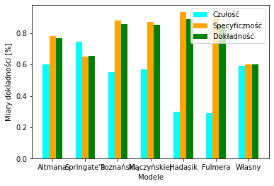

```python
import pandas as pd
import numpy as np
import math
dane = pd.read_csv('data1.csv', sep=";", header=0)
dane = dane.to_numpy()

print("Model Altmana")
results = [0,0,0,0] # tru pos, fal pos, fal neg, tru neg
wynik = [[0 for x in range(2)] for y in range(dane.shape[0])]
dobrze=0
for i in range(dane.shape[0]):
    wynik[i][0] = altman_model(dane[i][2],dane[i][5],dane[i][6],dane[i][7],dane[i][8])
    if wynik[i][0]<=1.8:
        wynik[i][1]=1
    else:
        wynik[i][1]=0
    if wynik[i][1] == 1 and dane[i][64] == 1:
        results[0]+=1
    elif wynik[i][1] == 1 and dane[i][64] == 0:
        results[1]+=1
    elif wynik[i][1] == 0 and dane[i][64] == 1:
        results[2]+=1
    else:
        results[3]+=1

print("\nTrue positive: " + str(round(results[0]/sum(results)*100, 2)) + "%")
print("False positive: " + str(round(results[1]/sum(results)*100, 2)) + "%")
print("False negative: " + str(round(results[2]/sum(results)*100, 2)) + "%")
print("True negative: " + str(round(results[3]/sum(results)*100, 2)) + "%")

tpr1 = results[0]/(results[0]+results[2])
spc1 = results[3]/(results[1]+results[3])
pv1 = (results[0]+results[3]) / sum(results)

print("\nCzułość: " + str(round(tpr1*100, 2)) + "%")
print("Specyficzność: " + str(round(spc1*100, 2)) + "%")
print("Dokładność: " + str(round(pv1*100, 2)) + "%")


print("\n\nModel Springate'a")

def springate_model(x1,x2,x3,x4):
    x1 = x1.replace(",",".")
    x2 = x2.replace(",",".")
    x3 = x3.replace(",",".")
    x4 = x4.replace(",",".")
    z = 1.03*float(x1) + 3.07*float(x2) + 0.66*float(x3) + 0.4*float(x4)
    return z
wynik2 = [[0 for x in range(2)] for y in range(dane.shape[0])]
dobrze2=0
results2 = [0, 0, 0, 0]
for i in range(dane.shape[0]):
    wynik2[i][0] = springate_model(dane[i][2], dane[i][6], dane[i][11], dane[i][8])
    if wynik2[i][0]<0.862:
        wynik2[i][1]=1
    else:
        wynik2[i][1]=0
    if wynik2[i][1] == 1 and dane[i][64] == 1:
        results2[0]+=1
    elif wynik2[i][1] == 1 and dane[i][64] == 0:
        results2[1]+=1
    elif wynik2[i][1] == 0 and dane[i][64] == 1:
        results2[2]+=1
    else:
        results2[3]+=1

print("\nTrue positive: " + str(round(results2[0]/sum(results2)*100, 2)) + "%")
print("False positive: " + str(round(results2[1]/sum(results2)*100, 2)) + "%")
print("False negative: " + str(round(results2[2]/sum(results2)*100, 2)) + "%")
print("True negative: " + str(round(results2[3]/sum(results2)*100, 2)) + "%")

tpr2 = results2[0]/(results2[0]+results2[2])
spc2 = results2[3]/(results2[1]+results2[3])
pv2 = (results2[0]+results2[3]) / sum(results2)

print("\nCzułość: " + str(round(tpr2*100, 2)) + "%")
print("Specyficzność: " + str(round(spc2*100, 2)) + "%")
print("Dokładność: " + str(round(pv2*100, 2)) + "%")


print("\n\nModel poznański")

wynik3 = [[0 for x in range(2)] for y in range(dane.shape[0])]
dobrze3=0
results3 = [0, 0, 0, 0]
for i in range(dane.shape[0]):
    wynik3[i][0] = poznanski_model(dane[i][0], dane[i][3], dane[i][9], dane[i][18])
    if wynik3[i][0]<=0:
        wynik3[i][1]=1
    else:
        wynik3[i][1]=0
    if wynik3[i][1] == 1 and dane[i][64] == 1:
        results3[0]+=1
    elif wynik3[i][1] == 1 and dane[i][64] == 0:
        results3[1]+=1
    elif wynik3[i][1] == 0 and dane[i][64] == 1:
        results3[2]+=1
    else:
        results3[3]+=1

print("\nTrue positive: " + str(round(results3[0]/sum(results3)*100, 2)) + "%")
print("False positive: " + str(round(results3[1]/sum(results3)*100, 2)) + "%")
print("False negative: " + str(round(results3[2]/sum(results3)*100, 2)) + "%")
print("True negative: " + str(round(results3[3]/sum(results3)*100, 2)) + "%")

tpr3 = results3[0]/(results3[0]+results3[2])
spc3 = results3[3]/(results3[1]+results3[3])
pv3 = (results3[0]+results3[3]) / sum(results3)

print("\nCzułość: " + str(round(tpr3*100, 2)) + "%")
print("Specyficzność: " + str(round(spc3*100, 2)) + "%")
print("Dokładność: " + str(round(pv3*100, 2)) + "%")



print("\n\nModel Mączyńskiej")


wynik4 = [[0 for x in range(2)] for y in range(dane.shape[0])]
dobrze4=0
results4 = [0, 0, 0, 0]
for i in range(dane.shape[0]):
    wynik4[i][0] = maczynska_model(dane[i][0],dane[i][9],dane[i][15],dane[i][3],dane[i][35])
    if wynik4[i][0]<=0:
        wynik4[i][1]=1
    else:
        wynik4[i][1]=0

    if wynik4[i][1] == 1 and dane[i][64] == 1:
        results4[0]+=1
    elif wynik4[i][1] == 1 and dane[i][64] == 0:
        results4[1]+=1
    elif wynik4[i][1] == 0 and dane[i][64] == 1:
        results4[2]+=1
    else:
        results4[3]+=1

print("\nTrue positive: " + str(round(results4[0]/sum(results4)*100, 2)) + "%")
print("False positive: " + str(round(results4[1]/sum(results4)*100, 2)) + "%")
print("False negative: " + str(round(results4[2]/sum(results4)*100, 2)) + "%")
print("True negative: " + str(round(results4[3]/sum(results4)*100, 2)) + "%")

tpr4 = results4[0]/(results4[0]+results4[2])
spc4 = results4[3]/(results4[1]+results4[3])
pv4 = (results4[0]+results4[3]) / sum(results4)

print("\nCzułość: " + str(round(tpr4*100, 2)) + "%")
print("Specyficzność: " + str(round(spc4*100, 2)) + "%")
print("Dokładność: " + str(round(pv4*100, 2)) + "%")



print("\n\nModel Hadasik")

wynik5 = [[0 for x in range(2)] for y in range(dane.shape[0])]
dobrze5=0
results5 = [0, 0, 0, 0]
for i in range(dane.shape[0]):
    wynik5[i][0] = hadasik_model(dane[i][3],dane[i][39],dane[i][1],dane[i][2],dane[i][61],dane[i][19])
    if wynik5[i][0]<=-0.34345:
        wynik5[i][1]=1
    else:
        wynik5[i][1]=0

    if wynik5[i][1] == 1 and dane[i][64] == 1:
        results5[0]+=1
    elif wynik5[i][1] == 1 and dane[i][64] == 0:
        results5[1]+=1
    elif wynik5[i][1] == 0 and dane[i][64] == 1:
        results5[2]+=1
    else:
        results5[3]+=1

print("\nTrue positive: " + str(round(results5[0]/sum(results5)*100, 2)) + "%")
print("False positive: " + str(round(results5[1]/sum(results5)*100, 2)) + "%")
print("False negative: " + str(round(results5[2]/sum(results5)*100, 2)) + "%")
print("True negative: " + str(round(results5[3]/sum(results5)*100, 2)) + "%")

tpr5 = results5[0]/(results5[0]+results5[2])
spc5 = results5[3]/(results5[1]+results5[3])
pv5 = (results5[0]+results5[3]) / sum(results5)

print("\nCzułość: " + str(round(tpr5*100, 2)) + "%")
print("Specyficzność: " + str(round(spc5*100, 2)) + "%")
print("Dokładność: " + str(round(pv5*100, 2)) + "%")


print("\n\nModel Fulmera")

wynik6 = [[0 for x in range(2)] for y in range(dane.shape[0])]
dobrze6=0
results6 = [0, 0, 0, 0]
for i in range(dane.shape[0]):
    wynik6[i][0] = fulmer_model(dane[i][5],dane[i][0],dane[i][17],dane[i][33],dane[i][1],dane[i][50],dane[i][28],dane[i][49],dane[i][6])
    if wynik6[i][0]<=0:
        wynik6[i][1]=1
    else:
        wynik6[i][1]=0

    if wynik6[i][1] == 1 and dane[i][64] == 1:
        results6[0]+=1
    elif wynik6[i][1] == 1 and dane[i][64] == 0:
        results6[1]+=1
    elif wynik6[i][1] == 0 and dane[i][64] == 1:
        results6[2]+=1
    else:
        results6[3]+=1

print("True positive: " + str(round(results6[0]/sum(results6)*100, 2)) + "%")
print("False positive: " + str(round(results6[1]/sum(results6)*100, 2)) + "%")
print("False negative: " + str(round(results6[2]/sum(results6)*100, 2)) + "%")
print("True negative: " + str(round(results6[3]/sum(results6)*100, 2)) + "%")

tpr6 = results6[0]/(results6[0]+results6[2])
spc6 = results6[3]/(results6[1]+results6[3])
pv6 = (results6[0]+results6[3]) / sum(results6)

print("\nCzułość: " + str(round(tpr6*100, 2)) + "%")
print("Specyficzność: " + str(round(spc6*100, 2)) + "%")
print("Dokładność: " + str(round(pv6*100, 2)) + "%")


print("\n\nWłasny model")
wynik7 = [[0 for x in range(2)] for y in range(dane.shape[0])]
dobrze7=0
results7 = [0, 0, 0, 0]
for i in range(dane.shape[0]):
    wynik7[i][0] = own_model(dane[i][2],dane[i][1],dane[i][8],dane[i][33],dane[i][17])
    if wynik7[i][0]<=1:
        wynik7[i][1]=1
    else:
        wynik7[i][1]=0

    if wynik7[i][1] == 1 and dane[i][64] == 1:
        results7[0]+=1
    elif wynik7[i][1] == 1 and dane[i][64] == 0:
        results7[1]+=1
    elif wynik7[i][1] == 0 and dane[i][64] == 1:
        results7[2]+=1
    else:
        results7[3]+=1

print("\nTrue positive: " + str(round(results7[0]/sum(results7)*100, 2)) + "%")
print("False positive: " + str(round(results7[1]/sum(results7)*100, 2)) + "%")
print("False negative: " + str(round(results7[2]/sum(results7)*100, 2)) + "%")
print("True negative: " + str(round(results7[3]/sum(results7)*100, 2)) + "%")

tpr7 = results7[0]/(results7[0]+results7[2])
spc7 = results7[3]/(results7[1]+results7[3])
pv7 = (results7[0]+results7[3]) / sum(results7)

print("\nCzułość: " + str(round(tpr7*100, 2)) + "%")
print("Specyficzność: " + str(round(spc7*100, 2)) + "%")
print("Dokładność: " + str(round(pv7*100, 2)) + "%")


import matplotlib.pyplot as plt
x = np.arange(7)
y1 = [tpr1, tpr2, tpr3, tpr4, tpr5, tpr6, tpr7]
y2 = [spc1, spc2, spc3, spc4, spc5, spc6, spc7]
y3 = [pv1, pv2, pv3, pv4, pv5, pv6, pv7]
width = 0.2
plt.bar(x-0.2, y1, width, color='cyan')
plt.bar(x, y2, width, color='orange')
plt.bar(x+0.2, y3, width, color='green')
plt.xticks(x, ['Altmana', 'Springate\'a', 'Poznański', 'Mączyńskiej', 'Hadasik', 'Fulmera', "Własny"])
plt.xlabel("Modele")
plt.ylabel("Miary dokładności [%]")
plt.legend(["Czułość", "Specyficzność", "Dokładność"])
plt.show()
```

W modelu Altmana firmy z "szarej strefy" przyjęto do klasy "niebankrutów" ze względu na ich zero-jedynkową klasyfikację w tym problemie. Mimo to wyższą precyzją mogą pochwalić się modele m.in poznański czy Hadasika, który z nich wszystkich jest najdokładniejszy, choć to model Springate'a ma największą czułość i najlepiej klasyfikował rzeczywistych bankrutów.

Ze względu na to, że liczebność klas bankrutów i niebankrutów jest nierówna (firm - bankrutów jest kilkanaście razy mniej), zauważalna jest duża różnica pomiędzy wartościami czułości i specyficzności w prawie każdym z modeli. Klas 0 - niebankrutów, jest znacznie więcej, dlatego łatwo jest założyć w ciemno i zaklasyfikować firmę do nie bankruta, a prawdopodobieństwo poprawności takiej klasyfikacji będzie wysokie co potiwerdzają powyższe wyniki. Natomiast ważniejsza jest umiejętność wyłapywania tych drugich przypadków - ważniejsze dla banku jest to, aby uniknąć klasyfikacji potencjalnego bankruta do niebankruta, niż klasyfikacji niebankruta do bankruta, ponieważ mniejszym problemem dla banku jest utracenie klienta (klasyfikacja niebankruta do bankruta) niż problemy z odzyskaniem należności (klasyfikacja bankruta to niebankruta).

Poniżej wykonano te same czynności, ale zastosowano ograniczono dane do takiej samej liczebności klas upadłości i nieupadłości.

```
Dane ograniczone do 200 firm upadłych i 200 nieupadłych


Model Altmana

True positive: 28.5%
False positive: 10.0%
False negative: 21.5%
True negative: 40.0%

Czułość: 57.0%
Specyficzność: 80.0%
Dokładność: 68.5%


Model Springate'a

True positive: 38.0%
False positive: 17.0%
False negative: 12.0%
True negative: 33.0%

Czułość: 76.0%
Specyficzność: 66.0%
Dokładność: 71.0%


Model poznanski

True positive: 27.75%
False positive: 7.5%
False negative: 22.25%
True negative: 42.5%

Czułość: 55.5%
Specyficzność: 85.0%
Dokładność: 70.25%


Model Maczynskiej
```

[output cut: 29 more lines]

```
Czułość: 31.0%
Specyficzność: 89.0%
Dokładność: 60.0%


Własny model

True positive: 30.25%
False positive: 21.25%
False negative: 19.75%
True negative: 28.75%

Czułość: 60.5%
Specyficzność: 57.5%
Dokładność: 59.0%
```

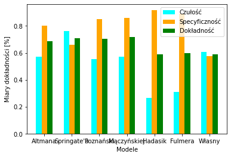

```python
print("Dane ograniczone do 200 firm upadłych i 200 nieupadłych\n")
good = np.array([x for x in dane if x[-1] == 1])
bad  = np.array([x for x in dane if x[-1] == 0])
good2 = good[np.random.choice(good.shape[0], 200, replace=False)]
bad2 = bad[np.random.choice(bad.shape[0], 200, replace=False)]
dane2 = np.concatenate((bad2, good2), axis=0)


print("\nModel Altmana")
results = [0,0,0,0]
wynik = [[0 for x in range(2)] for y in range(dane2.shape[0])]
dobrze=0
for i in range(dane2.shape[0]):
    wynik[i][0] = altman_model(dane2[i][2],dane2[i][5],dane2[i][6],dane2[i][7],dane2[i][8])
    if wynik[i][0]<=1.8:
        wynik[i][1]=1
    else:
        wynik[i][1]=0
    if wynik[i][1] == 1 and dane2[i][64] == 1:
        results[0]+=1
    elif wynik[i][1] == 1 and dane2[i][64] == 0:
        results[1]+=1
    elif wynik[i][1] == 0 and dane2[i][64] == 1:
        results[2]+=1
    else:
        results[3]+=1
print("\nTrue positive: " + str(round(results[0]/sum(results)*100, 2)) + "%")
print("False positive: " + str(round(results[1]/sum(results)*100, 2)) + "%")
print("False negative: " + str(round(results[2]/sum(results)*100, 2)) + "%")
print("True negative: " + str(round(results[3]/sum(results)*100, 2)) + "%")

tpr1 = results[0]/(results[0]+results[2])
spc1 = results[3]/(results[1]+results[3])
pv1 = (results[0]+results[3]) / sum(results)

print("\nCzułość: " + str(round(tpr1*100, 2)) + "%")
print("Specyficzność: " + str(round(spc1*100, 2)) + "%")
print("Dokładność: " + str(round(pv1*100, 2)) + "%")



print("\n\nModel Springate'a")

wynik2 = [[0 for x in range(2)] for y in range(dane2.shape[0])]
dobrze2=0
results2 = [0, 0, 0, 0]
for i in range(dane2.shape[0]):
    wynik2[i][0] = springate_model(dane2[i][2], dane2[i][6], dane2[i][11], dane2[i][8])
    if wynik2[i][0]<0.862:
        wynik2[i][1]=1
    else:
        wynik2[i][1]=0
    if wynik2[i][1] == 1 and dane2[i][64] == 1:
        results2[0]+=1
    elif wynik2[i][1] == 1 and dane2[i][64] == 0:
        results2[1]+=1
    elif wynik2[i][1] == 0 and dane2[i][64] == 1:
        results2[2]+=1
    else:
        results2[3]+=1

print("\nTrue positive: " + str(round(results2[0]/sum(results2)*100, 2)) + "%")
print("False positive: " + str(round(results2[1]/sum(results2)*100, 2)) + "%")
print("False negative: " + str(round(results2[2]/sum(results2)*100, 2)) + "%")
print("True negative: " + str(round(results2[3]/sum(results2)*100, 2)) + "%")

tpr2 = results2[0]/(results2[0]+results2[2])
spc2 = results2[3]/(results2[1]+results2[3])
pv2 = (results2[0]+results2[3]) / sum(results2)

print("\nCzułość: " + str(round(tpr2*100, 2)) + "%")
print("Specyficzność: " + str(round(spc2*100, 2)) + "%")
print("Dokładność: " + str(round(pv2*100, 2)) + "%")


print("\n\nModel poznanski")

wynik3 = [[0 for x in range(2)] for y in range(dane2.shape[0])]
dobrze3=0
results3 = [0, 0, 0, 0]
for i in range(dane2.shape[0]):
    wynik3[i][0] = poznanski_model(dane2[i][0], dane2[i][3], dane2[i][9], dane2[i][18])
    if wynik3[i][0]<=0:
        wynik3[i][1]=1
    else:
        wynik3[i][1]=0
    if wynik3[i][1] == 1 and dane2[i][64] == 1:
        results3[0]+=1
    elif wynik3[i][1] == 1 and dane2[i][64] == 0:
        results3[1]+=1
    elif wynik3[i][1] == 0 and dane2[i][64] == 1:
        results3[2]+=1
    else:
        results3[3]+=1

print("\nTrue positive: " + str(round(results3[0]/sum(results3)*100, 2)) + "%")
print("False positive: " + str(round(results3[1]/sum(results3)*100, 2)) + "%")
print("False negative: " + str(round(results3[2]/sum(results3)*100, 2)) + "%")
print("True negative: " + str(round(results3[3]/sum(results3)*100, 2)) + "%")

tpr3 = results3[0]/(results3[0]+results3[2])
spc3 = results3[3]/(results3[1]+results3[3])
pv3 = (results3[0]+results3[3]) / sum(results3)

print("\nCzułość: " + str(round(tpr3*100, 2)) + "%")
print("Specyficzność: " + str(round(spc3*100, 2)) + "%")
print("Dokładność: " + str(round(pv3*100, 2)) + "%")


print("\n\nModel Maczynskiej")

wynik4 = [[0 for x in range(2)] for y in range(dane2.shape[0])]
dobrze4=0
results4 = [0, 0, 0, 0]
for i in range(dane2.shape[0]):
    wynik4[i][0] = maczynska_model(dane2[i][0],dane2[i][9],dane2[i][15],dane2[i][3],dane2[i][35])
    if wynik4[i][0]<=0:
        wynik4[i][1]=1
    else:
        wynik4[i][1]=0

    if wynik4[i][1] == 1 and dane2[i][64] == 1:
        results4[0]+=1
    elif wynik4[i][1] == 1 and dane2[i][64] == 0:
        results4[1]+=1
    elif wynik4[i][1] == 0 and dane2[i][64] == 1:
        results4[2]+=1
    else:
        results4[3]+=1

print("\nTrue positive: " + str(round(results4[0]/sum(results4)*100, 2)) + "%")
print("False positive: " + str(round(results4[1]/sum(results4)*100, 2)) + "%")
print("False negative: " + str(round(results4[2]/sum(results4)*100, 2)) + "%")
print("True negative: " + str(round(results4[3]/sum(results4)*100, 2)) + "%")

tpr4 = results4[0]/(results4[0]+results4[2])
spc4 = results4[3]/(results4[1]+results4[3])
pv4 = (results4[0]+results4[3]) / sum(results4)

print("\nCzułość: " + str(round(tpr4*100, 2)) + "%")
print("Specyficzność: " + str(round(spc4*100, 2)) + "%")
print("Dokładność: " + str(round(pv4*100, 2)) + "%")



print("\n\nModel Hadasik")
wynik5 = [[0 for x in range(2)] for y in range(dane2.shape[0])]
dobrze5=0
results5 = [0, 0, 0, 0]
for i in range(dane2.shape[0]):
    wynik5[i][0] = hadasik_model(dane2[i][3],dane2[i][39],dane2[i][1],dane2[i][2],dane2[i][61],dane2[i][19])
    if wynik5[i][0]<=-0.34345:
        wynik5[i][1]=1
    else:
        wynik5[i][1]=0

    if wynik5[i][1] == 1 and dane2[i][64] == 1:
        results5[0]+=1
    elif wynik5[i][1] == 1 and dane2[i][64] == 0:
        results5[1]+=1
    elif wynik5[i][1] == 0 and dane2[i][64] == 1:
        results5[2]+=1
    else:
        results5[3]+=1

print("\nTrue positive: " + str(round(results5[0]/sum(results5)*100, 2)) + "%")
print("False positive: " + str(round(results5[1]/sum(results5)*100, 2)) + "%")
print("False negative: " + str(round(results5[2]/sum(results5)*100, 2)) + "%")
print("True negative: " + str(round(results5[3]/sum(results5)*100, 2)) + "%")

tpr5 = results5[0]/(results5[0]+results5[2])
spc5 = results5[3]/(results5[1]+results5[3])
pv5 = (results5[0]+results5[3]) / sum(results5)

print("\nCzułość: " + str(round(tpr5*100, 2)) + "%")
print("Specyficzność: " + str(round(spc5*100, 2)) + "%")
print("Dokładność: " + str(round(pv5*100, 2)) + "%")

print("\n\nModel Fulmera")
wynik6 = [[0 for x in range(2)] for y in range(dane2.shape[0])]
dobrze6=0
results6 = [0, 0, 0, 0]
for i in range(dane2.shape[0]):
    wynik6[i][0] = fulmer_model(dane2[i][5],dane2[i][0],dane2[i][17],dane2[i][33],dane2[i][1],dane2[i][50],dane2[i][28],dane2[i][49],dane2[i][6])
    if wynik6[i][0]<=0:
        wynik6[i][1]=1
    else:
        wynik6[i][1]=0

    if wynik6[i][1] == 1 and dane2[i][64] == 1:
        results6[0]+=1
    elif wynik6[i][1] == 1 and dane2[i][64] == 0:
        results6[1]+=1
    elif wynik6[i][1] == 0 and dane2[i][64] == 1:
        results6[2]+=1
    else:
        results6[3]+=1

print("True positive: " + str(round(results6[0]/sum(results6)*100, 2)) + "%")
print("False positive: " + str(round(results6[1]/sum(results6)*100, 2)) + "%")
print("False negative: " + str(round(results6[2]/sum(results6)*100, 2)) + "%")
print("True negative: " + str(round(results6[3]/sum(results6)*100, 2)) + "%")

tpr6 = results6[0]/(results6[0]+results6[2])
spc6 = results6[3]/(results6[1]+results6[3])
pv6 = (results6[0]+results6[3]) / sum(results6)

print("\nCzułość: " + str(round(tpr6*100, 2)) + "%")
print("Specyficzność: " + str(round(spc6*100, 2)) + "%")
print("Dokładność: " + str(round(pv6*100, 2)) + "%")



print("\n\nWłasny model")
wynik7 = [[0 for x in range(2)] for y in range(dane2.shape[0])]
dobrze7=0
results7 = [0, 0, 0, 0]
for i in range(dane2.shape[0]):
    wynik7[i][0] = own_model(dane2[i][2],dane2[i][1],dane2[i][8],dane2[i][33],dane2[i][17])
    if wynik7[i][0]<=1:
        wynik7[i][1]=1
    else:
        wynik7[i][1]=0

    if wynik7[i][1] == 1 and dane2[i][64] == 1:
        results7[0]+=1
    elif wynik7[i][1] == 1 and dane2[i][64] == 0:
        results7[1]+=1
    elif wynik7[i][1] == 0 and dane2[i][64] == 1:
        results7[2]+=1
    else:
        results7[3]+=1

print("\nTrue positive: " + str(round(results7[0]/sum(results7)*100, 2)) + "%")
print("False positive: " + str(round(results7[1]/sum(results7)*100, 2)) + "%")
print("False negative: " + str(round(results7[2]/sum(results7)*100, 2)) + "%")
print("True negative: " + str(round(results7[3]/sum(results7)*100, 2)) + "%")

tpr7 = results7[0]/(results7[0]+results7[2])
spc7 = results7[3]/(results7[1]+results7[3])
pv7 = (results7[0]+results7[3]) / sum(results7)

print("\nCzułość: " + str(round(tpr7*100, 2)) + "%")
print("Specyficzność: " + str(round(spc7*100, 2)) + "%")
print("Dokładność: " + str(round(pv7*100, 2)) + "%")



import matplotlib.pyplot as plt
x = np.arange(7)
y1 = [tpr1, tpr2, tpr3, tpr4, tpr5, tpr6, tpr7]
y2 = [spc1, spc2, spc3, spc4, spc5, spc6, spc7]
y3 = [pv1, pv2, pv3, pv4, pv5, pv6, pv7]
width = 0.2
plt.bar(x-0.2, y1, width, color='cyan')
plt.bar(x, y2, width, color='orange')
plt.bar(x+0.2, y3, width, color='green')
plt.xticks(x, ['Altmana', 'Springate\'a', 'Poznański', 'Mączyńskiej', 'Hadasik', 'Fulmera', "Własny"])
plt.xlabel("Modele")
plt.ylabel("Miary dokładności [%]")
plt.legend(["Czułość", "Specyficzność", "Dokładność"])
plt.show()
```

Wnioski:

Najgorszy model po zbalansowaniu danych to Model Hadasik. Chociaż jego specyficzność jest wysoka (91.5%), ma bardzo niską czułość (26.5%) i niską dokładność (59.0%).

Źródła: https://eanaliza.pl/modele-predykcji-bankructwa https://www.statsoft.pl/textbook/stathome_stat.html?https%3A%2F%2Fwww.statsoft.pl%2Ftextbook%2Fstdiscan.html https://pl.wikipedia.org/wiki/Liniowa_analiza_dyskryminacyjna